# Лабораторная работа №1

Операционные системы

Лебеденко Е.В.

Российский университет дружбы народов, Москва, Россия

24 февраля 2026

# Информация

## Докладчик

- Лебеденко Елена Викторовна
- Студент НКАбд-04-25
- Российский университет дружбы народов
- 1032253535@rudn.ru

# Цель работы

Целью данной работы является приобретение практических навыков установки операционной системы на виртуальную машину, настройки минимально необходимых для дальнейшей работы сервисов.

# Задание

- Установка Linux на VirtualBox
- Установка необходимого ПО
- Первоначальная настройка ОС для дальнейшей работы

# Теоретическое введение

QEMU (Quick Emulator) — это бесплатный универсальный эмулятор и виртуализатор с открытым исходным кодом, который позволяет запускать операционные системы (ОС), созданные для одной архитектуры (например, ARM), на другой (например, x86/Intel). Он эмулирует различное аппаратное обеспечение, позволяя тестировать ПО и запускать виртуальные машины.

# Выполнение лабораторной работы

Создадаю образ виртуального диска: 60GB, формат qcow2

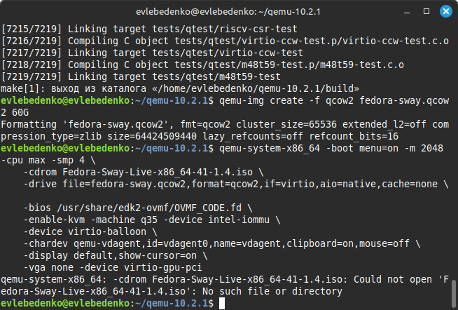

Создание образа

Запускаю виртуальную машину (с небольшими изменениями в программе)

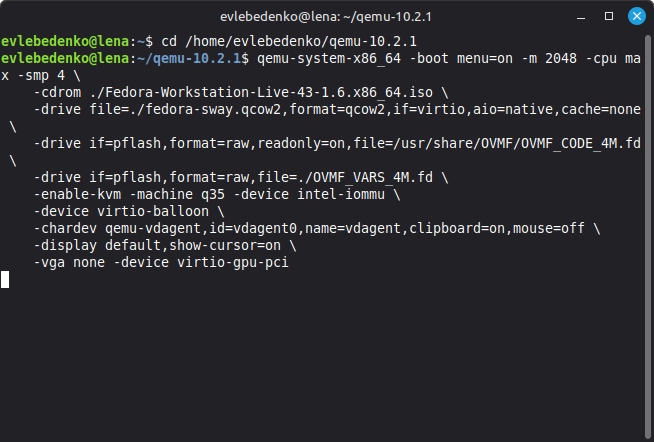

Запуск виртуальной машины

Выбераю Start

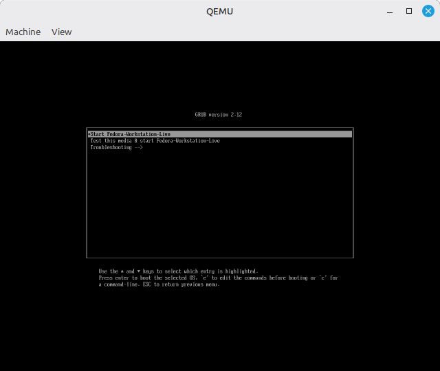

Start

Установка системы

[figure not shown]

Установка системы

Для удобства создаю командный файл

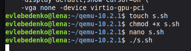

Создание командного файла

Устанавливаю средства разработки, обновляю пакеты

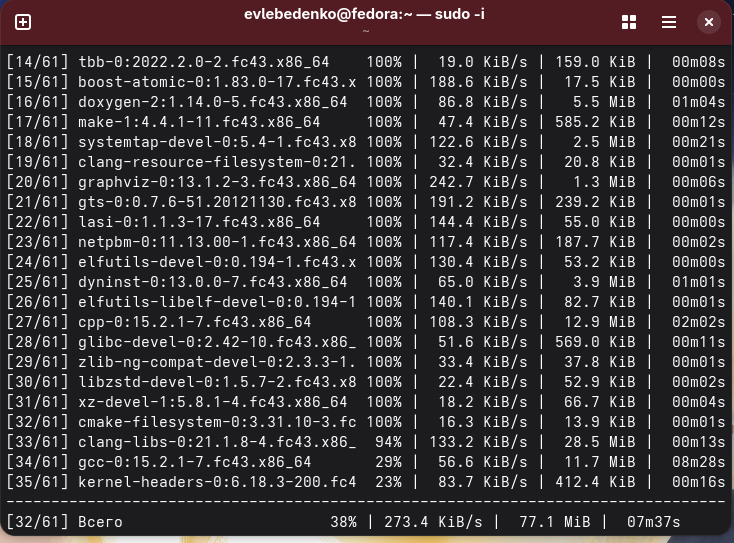

Программы для удобства работы в консоли

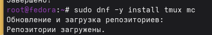

Установка tmux

При необходимости можно использовать автоматическое обновление. Установливаю программное обеспечение, запускаю таймер.

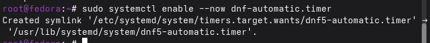

Автоматическое обновление

Отключение SELinux

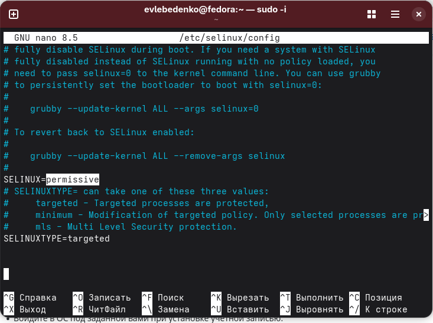

Отключение SELinux

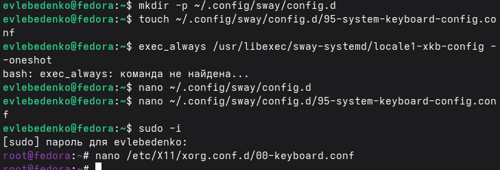

Настройка раскладки клавиатуры

Создаю пользователя, задаю пароль, устанавливаю имя хоста

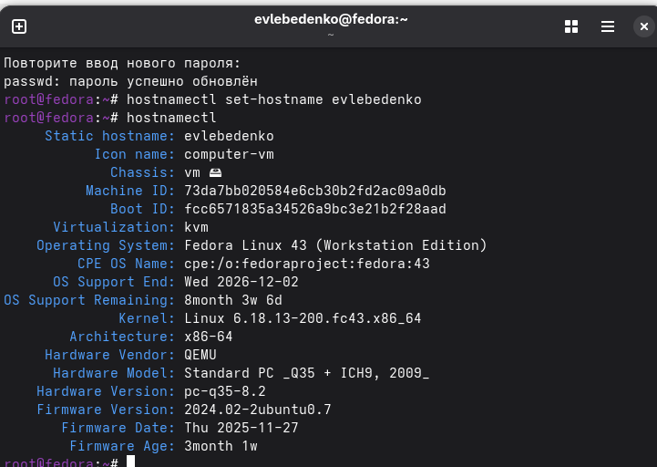

Установка имени пользователя и названия хоста

Установка pandoc, pandoc-crossref, TeXlive

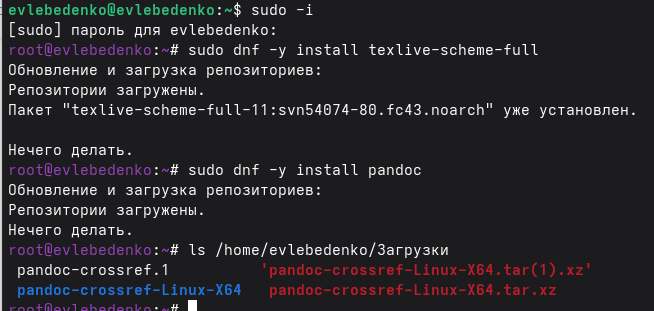

## Домашнее задание

Получить информацию о компьютере

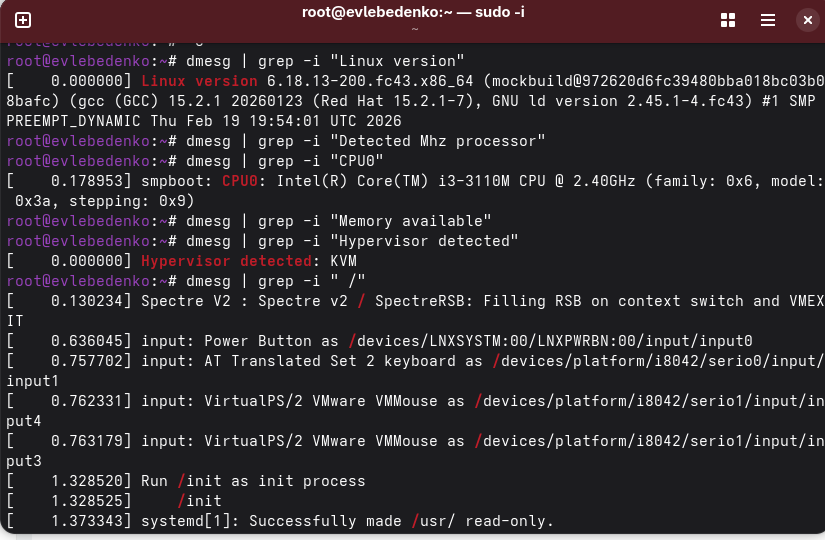

дз

# Выводы

В ходе выполнения данной работы я приобрела практические навыки установки операционной системы на виртуальную машину, настройки минимально необходимых для дальнейшей работы сервисов.